# Applied Multilinear Regression To Predict TV Show Ratings

## Problem Statement

### Business Context

Streamist is a streaming company that streams web series and movies for a worldwide audience. Every content on their portal is rated by the viewers, and the portal also provides other information for the content like the number of people who have watched it, the number of people who want to watch it, the number of episodes, duration of an episode, etc.

They are currently focusing on the anime available in their portal, and want to identify the most important factors involved in rating an anime. You as a data scientist at Streamist are tasked with identifying the important factors and building a predictive model to predict the rating on an anime.

## Key Take Aways and Business Impact

There are about 30 key features that can be used to effectively predict the rating of a new anime in this data set.

A few of them include:

- The duration of an episode in minutes.
- If there is a content warning or not.
- If the anime is based on a Manga.
- The studio that produced the show.

Examples of business applications for this prediction model:

- **Marketing** - Predicting which anime are likely to receive high ratings can significantly enhance the marketing strategy. Allocating advertising funds to promote content expected to be well-received will ensure a healthy return on investment.
- **Content Selection** - In today's increasingly competitive and costly streaming landscape, users are becoming more discerning about where they spend their time and money. By predicting which new animes are likely to resonate with the audience, Streamist can strategically enhance user engagement, retention, and overall satisfaction. This proactive approach not only ensures that Streamist is offering content that appeals to their viewers but also maximizes the return on their investment in content acquisition and royalty fees.
- **Recommendations** - By leveraging this prediction model, Streamist can effectively recommend new shows that have not yet established a rating. This proactive strategy ensures that promising new content gets the visibility it deserves. By promoting and recommending these high-potential shows to current users, Streamist can significantly enhance user engagement.

## Data Dictionary

- title - the title of anime
- description - the synopsis of the plot
- mediaType - format of publication
- eps - number of episodes (movies are considered 1 episode)
- duration - duration of an episode in minutes
- ongoing - whether it is ongoing
- sznOfRelease - the season of release (Winter, Spring, Fall)
- years_running - number of years the anime ran/is running
- studio_primary - primary studio of production
- studios_colab - whether there was a collaboration between studios to produce the anime
- contentWarn - whether anime has a content warning
- watched - number of users that completed it
- watching - number of users that are watching it
- wantWatch - number of users that want to watch it
- dropped - number of users that dropped it before completion
- rating - average user rating
- votes - number of votes that contribute to rating
- tag_Based_on_a_Manga - whether the anime is based on a manga
- tag_Comedy - whether the anime is of Comedy genre
- tag_Action - whether the anime is of Action genre
- tag_Fantasy - whether the anime is of Fantasy genre
- tag_Sci_Fi - whether the anime is of Sci-Fi genre
- tag_Shounen - whether the anime has a tag Shounen
- tag_Original_Work - whether the anime is an original work
- tag_Non_Human_Protagonists - whether the anime has any non-human protagonists
- tag_Drama - whether the anime is of Drama genre
- tag_Adventure - whether the anime is of Adventure genre
- tag_Family_Friendly - whether the anime is family-friendly
- tag_Short_Episodes - whether the anime has short episodes
- tag_School_Life - whether the anime is regarding school life
- tag_Romance - whether the anime is of Romance genre
- tag_Shorts - whether the anime has a tag Shorts
- tag_Slice_of_Life - whether the anime has a tag Slice of Life
- tag_Seinen - whether the anime has a tag Seinen
- tag_Supernatural - whether the anime has a tag Supernatural
- tag_Magic - whether the anime has a tag Magic
- tag_Animal_Protagonists - whether the anime has animal protagonists
- tag_Ecchi - whether the anime has a tag Ecchi
- tag_Mecha - whether the anime has a tag Mecha
- tag_Based_on_a_Light_Novel - whether the anime is based on a light novel
- tag_CG_Animation - whether the anime has a tag CG Animation
- tag_Superpowers - whether the anime has a tag Superpowers
- tag_Others - whether the anime has other tags
- tag_is_missing - whether tag is missing or not

## Import Libraries

```python
import numpy as np
import pandas as pd
import matplotlib.pyplot as plt
import matplotlib.ticker as ticker
import seaborn as sns
from sklearn.linear_model import LinearRegression
from sklearn.decomposition import PCA
from sklearn.preprocessing import StandardScaler
from sklearn.model_selection import train_test_split
from sklearn.metrics import mean_squared_error
from sklearn.metrics import root_mean_squared_error
from sklearn.feature_selection import RFE
```

```python
df = pd.read_csv('/content/anime_data.csv')
```

## EDA

```python
df.head(5)
```

|  | title | description | mediaType | eps | duration | ongoing | sznOfRelease | years_running | studio_primary | studios_colab | ... | tag_Supernatural | tag_Magic | tag_Animal_Protagonists | tag_Ecchi | tag_Mecha | tag_Based_on_a_Light_Novel | tag_CG_Animation | tag_Superpowers | tag_Others | tag_missing |
| --- | --- | --- | --- | --- | --- | --- | --- | --- | --- | --- | --- | --- | --- | --- | --- | --- | --- | --- | --- | --- | --- |
| 0 | Fullmetal Alchemist: Brotherhood | The foundation of alchemy is based on the law ... | TV | 64 | NaN | False | Spring | 1 | Bones | 0 | ... | 0 | 0 | 0 | 0 | 0 | 0 | 0 | 0 | 0 | 0 |
| 1 | your name. | Mitsuha and Taki are two total strangers livin... | Movie | 1 | 107.0 | False | is_missing | 0 | Others | 0 | ... | 1 | 0 | 0 | 0 | 0 | 0 | 0 | 0 | 0 | 0 |
| 2 | A Silent Voice | After transferring into a new school, a deaf g... | Movie | 1 | 130.0 | False | is_missing | 0 | Kyoto Animation | 0 | ... | 0 | 0 | 0 | 0 | 0 | 0 | 0 | 0 | 0 | 0 |
| 3 | Haikyuu!! Karasuno High School vs Shiratorizaw... | Picking up where the second season ended, the ... | TV | 10 | NaN | False | Fall | 0 | Production I.G | 0 | ... | 0 | 0 | 0 | 0 | 0 | 0 | 0 | 0 | 0 | 0 |
| 4 | Attack on Titan 3rd Season: Part II | The battle to retake Wall Maria begins now! Wi... | TV | 10 | NaN | False | Spring | 0 | Others | 0 | ... | 0 | 0 | 0 | 0 | 0 | 0 | 0 | 0 | 0 | 0 |

5 rows × 44 columns

```python
df.info()
```

```
<class 'pandas.core.frame.DataFrame'>
RangeIndex: 12101 entries, 0 to 12100
Data columns (total 44 columns):
 #   Column                      Non-Null Count  Dtype
---  ------                      --------------  -----
 0   title                       12101 non-null  object
 1   description                 7633 non-null   object
 2   mediaType                   12101 non-null  object
 3   eps                         12101 non-null  int64
 4   duration                    7465 non-null   float64
 5   ongoing                     12101 non-null  bool
 6   sznOfRelease                12101 non-null  object
 7   years_running               12101 non-null  int64
 8   studio_primary              12101 non-null  object
 9   studios_colab               12101 non-null  int64
```

[output cut: 36 more lines]

```python
print(f"This data set has {df.shape[0]} rows and {df.shape[1]} columns.")
```

```
This data set has 12101 rows and 44 columns.
```

```python
#Check for duplicates
df.duplicated().sum()
```

```
0
```

This data has no duplicate values.

```python
#Statistics summary of the dataset.
df.describe().T
```

|  | count | mean | std | min | 25% | 50% | 75% | max |
| --- | --- | --- | --- | --- | --- | --- | --- | --- |
| eps | 12101.0 | 13.393356 | 57.925097 | 1.000 | 1.000 | 2.000 | 12.000 | 2527.000 |
| duration | 7465.0 | 24.230141 | 31.468171 | 1.000 | 4.000 | 8.000 | 30.000 | 163.000 |
| years_running | 12101.0 | 0.283200 | 1.152234 | 0.000 | 0.000 | 0.000 | 0.000 | 51.000 |
| studios_colab | 12101.0 | 0.051649 | 0.221326 | 0.000 | 0.000 | 0.000 | 0.000 | 1.000 |
| contentWarn | 12101.0 | 0.115362 | 0.319472 | 0.000 | 0.000 | 0.000 | 0.000 | 1.000 |
| watched | 12101.0 | 2862.605694 | 7724.347024 | 0.000 | 55.000 | 341.000 | 2026.000 | 161567.000 |
| watching | 12101.0 | 256.334435 | 1380.840902 | 0.000 | 2.000 | 14.000 | 100.000 | 74537.000 |
| wantWatch | 12101.0 | 1203.681431 | 2294.327380 | 0.000 | 49.000 | 296.000 | 1275.000 | 28541.000 |
| dropped | 12101.0 | 151.568383 | 493.931710 | 0.000 | 3.000 | 12.000 | 65.000 | 19481.000 |
| rating | 12101.0 | 2.949037 | 0.827385 | 0.844 | 2.304 | 2.965 | 3.616 | 4.702 |
| votes | 12101.0 | 2088.124700 | 5950.332228 | 10.000 | 34.000 | 219.000 | 1414.000 | 131067.000 |
| tag_Based_on_a_Manga | 12101.0 | 0.290802 | 0.454151 | 0.000 | 0.000 | 0.000 | 1.000 | 1.000 |
| tag_Comedy | 12101.0 | 0.272870 | 0.445453 | 0.000 | 0.000 | 0.000 | 1.000 | 1.000 |
| tag_Action | 12101.0 | 0.231221 | 0.421631 | 0.000 | 0.000 | 0.000 | 0.000 | 1.000 |
| tag_Fantasy | 12101.0 | 0.181555 | 0.385493 | 0.000 | 0.000 | 0.000 | 0.000 | 1.000 |
| tag_Sci_Fi | 12101.0 | 0.166267 | 0.372336 | 0.000 | 0.000 | 0.000 | 0.000 | 1.000 |
| tag_Shounen | 12101.0 | 0.144864 | 0.351978 | 0.000 | 0.000 | 0.000 | 0.000 | 1.000 |
| tag_Original_Work | 12101.0 | 0.135195 | 0.341946 | 0.000 | 0.000 | 0.000 | 0.000 | 1.000 |
| tag_Non_Human_Protagonists | 12101.0 | 0.112470 | 0.315957 | 0.000 | 0.000 | 0.000 | 0.000 | 1.000 |
| tag_Drama | 12101.0 | 0.106107 | 0.307987 | 0.000 | 0.000 | 0.000 | 0.000 | 1.000 |
| tag_Adventure | 12101.0 | 0.103793 | 0.305005 | 0.000 | 0.000 | 0.000 | 0.000 | 1.000 |
| tag_Family_Friendly | 12101.0 | 0.097017 | 0.295993 | 0.000 | 0.000 | 0.000 | 0.000 | 1.000 |
| tag_Short_Episodes | 12101.0 | 0.096934 | 0.295880 | 0.000 | 0.000 | 0.000 | 0.000 | 1.000 |
| tag_School_Life | 12101.0 | 0.092306 | 0.289470 | 0.000 | 0.000 | 0.000 | 0.000 | 1.000 |
| tag_Romance | 12101.0 | 0.092141 | 0.289237 | 0.000 | 0.000 | 0.000 | 0.000 | 1.000 |
| tag_Shorts | 12101.0 | 0.089662 | 0.285709 | 0.000 | 0.000 | 0.000 | 0.000 | 1.000 |
| tag_Slice_of_Life | 12101.0 | 0.080820 | 0.272569 | 0.000 | 0.000 | 0.000 | 0.000 | 1.000 |
| tag_Seinen | 12101.0 | 0.077101 | 0.266763 | 0.000 | 0.000 | 0.000 | 0.000 | 1.000 |
| tag_Supernatural | 12101.0 | 0.070903 | 0.256674 | 0.000 | 0.000 | 0.000 | 0.000 | 1.000 |
| tag_Magic | 12101.0 | 0.064292 | 0.245283 | 0.000 | 0.000 | 0.000 | 0.000 | 1.000 |
| tag_Animal_Protagonists | 12101.0 | 0.060326 | 0.238099 | 0.000 | 0.000 | 0.000 | 0.000 | 1.000 |
| tag_Ecchi | 12101.0 | 0.057433 | 0.232678 | 0.000 | 0.000 | 0.000 | 0.000 | 1.000 |
| tag_Mecha | 12101.0 | 0.054541 | 0.227091 | 0.000 | 0.000 | 0.000 | 0.000 | 1.000 |
| tag_Based_on_a_Light_Novel | 12101.0 | 0.053384 | 0.224807 | 0.000 | 0.000 | 0.000 | 0.000 | 1.000 |
| tag_CG_Animation | 12101.0 | 0.050079 | 0.218116 | 0.000 | 0.000 | 0.000 | 0.000 | 1.000 |
| tag_Superpowers | 12101.0 | 0.044624 | 0.206486 | 0.000 | 0.000 | 0.000 | 0.000 | 1.000 |
| tag_Others | 12101.0 | 0.090654 | 0.287128 | 0.000 | 0.000 | 0.000 | 0.000 | 1.000 |
| tag_missing | 12101.0 | 0.025866 | 0.158741 | 0.000 | 0.000 | 0.000 | 0.000 | 1.000 |

### Check the unique values in each columns.

```python
#Remove these cols as they will have a lot of unique values
cat_col = ["mediaType", "ongoing", "sznOfRelease", "studio_primary"]

#Print the number of unique values in each col.
for col in cat_col:
  print(df[col].value_counts())
  print('-' * 25)
```

```
mediaType
TV             3993
Movie          1928
OVA            1770
Music Video    1290
Web            1170
DVD Special     803
Other           580
TV Special      504
is_missing       63
Name: count, dtype: int64
-------------------------
ongoing
False    11986
True       115
Name: count, dtype: int64
-------------------------
sznOfRelease
is_missing    8554
Spring        1135
Fall          1011
Winter         717
Summer         684
Name: count, dtype: int64
-------------------------
studio_primary
Others                  4340
is_missing              3208
Toei Animation           636
Sunrise                  430
J.C. Staff               341
MADHOUSE                 337
TMS Entertainment        317
Production I.G           271
Studio Deen              260
Studio Pierrot           221
OLM                      210
A-1 Pictures             194
AIC                      167
Shin-Ei Animation        164
Nippon Animation         145
Tatsunoko Production     144
DLE                      130
GONZO                    124
Bones                    121
Shaft                    118
XEBEC                    117
Kyoto Animation          106
Name: count, dtype: int64
-------------------------
```

### Cheking the missing values

```python
#missing values in each col.
missing_values = df.isnull().sum()
missing_values = missing_values.sort_values(ascending=False)
print(missing_values)
```

```
duration                      4636
description                   4468
tag_Seinen                       0
tag_Non_Human_Protagonists       0
tag_Drama                        0
tag_Adventure                    0
tag_Family_Friendly              0
tag_Short_Episodes               0
tag_School_Life                  0
tag_Romance                      0
tag_Shorts                       0
tag_Slice_of_Life                0
title                            0
tag_Original_Work                0
tag_Magic                        0
tag_Animal_Protagonists          0
tag_Ecchi                        0
tag_Mecha                        0
tag_Based_on_a_Light_Novel       0
tag_CG_Animation                 0
tag_Superpowers                  0
tag_Others                       0
tag_Supernatural                 0
tag_Shounen                      0
tag_Sci_Fi                       0
tag_Fantasy                      0
mediaType                        0
eps                              0
ongoing                          0
sznOfRelease                     0
years_running                    0
studio_primary                   0
studios_colab                    0
contentWarn                      0
watched                          0
watching                         0
wantWatch                        0
dropped                          0
rating                           0
votes                            0
tag_Based_on_a_Manga             0
tag_Comedy                       0
tag_Action                       0
tag_missing                      0
dtype: int64
```

It's impossible to impute values for the description column. We can impute the median value for the duration column. Median imputation is important in this instance because the duration column is heavily right skewed.

```python
#Median imputation.
df['duration'] = df['duration'].fillna(df['duration'].median())
#Drop the description column.
df = df.drop('description', axis=1)
```

```python
#missing values in each col.
missing_values = df.isnull().sum()
missing_values = missing_values.sort_values(ascending=False)
print(missing_values)
```

```
title                         0
tag_Seinen                    0
tag_Drama                     0
tag_Adventure                 0
tag_Family_Friendly           0
tag_Short_Episodes            0
tag_School_Life               0
tag_Romance                   0
tag_Shorts                    0
tag_Slice_of_Life             0
tag_Supernatural              0
tag_Original_Work             0
tag_Magic                     0
tag_Animal_Protagonists       0
tag_Ecchi                     0
tag_Mecha                     0
tag_Based_on_a_Light_Novel    0
tag_CG_Animation              0
tag_Superpowers               0
tag_Others                    0
tag_Non_Human_Protagonists    0
tag_Shounen                   0
mediaType                     0
watched                       0
eps                           0
duration                      0
ongoing                       0
sznOfRelease                  0
years_running                 0
studio_primary                0
studios_colab                 0
contentWarn                   0
watching                      0
tag_Sci_Fi                    0
wantWatch                     0
dropped                       0
rating                        0
votes                         0
tag_Based_on_a_Manga          0
tag_Comedy                    0
tag_Action                    0
tag_Fantasy                   0
tag_missing                   0
dtype: int64
```

There are no more missing values in the data.

## Univariate Analysis

### Rating

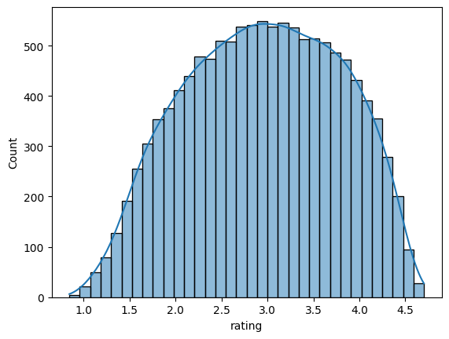

```python
sns.histplot(data=df, x="rating", kde=True)
```

```python
median_rating = df['rating'].median()
print(median_rating)
```

```
2.965
```

### EPS

Eps is the number of episodes per anime.

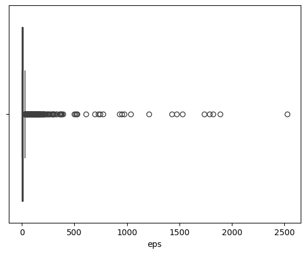

```python
sns.boxplot(data=df, x='eps')
```

This distribution is heavily right-skewed. This is because moveis make up a large proportion of the data, and movies count as one episode per the data dictionary.

### Duration

This column represents the duration of each episode.

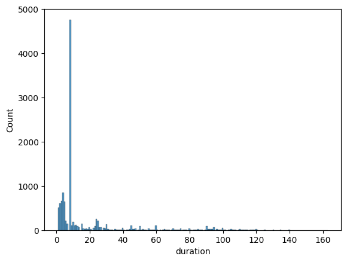

```python
sns.histplot(data=df, x='duration')
```

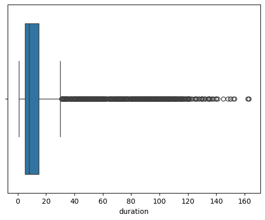

```python
sns.boxplot(data=df, x='duration')
```

The duration distribution is heavily right skewed.

### media_type

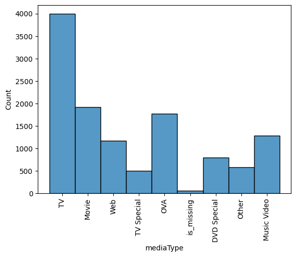

```python
sns.histplot(data=df, x='mediaType')
plt.xticks(rotation=90);
```

The most common media types in this data set are TV, movie, and OVA. It is worth noting that the is_missing category is the least frequent option.

### studio_primary

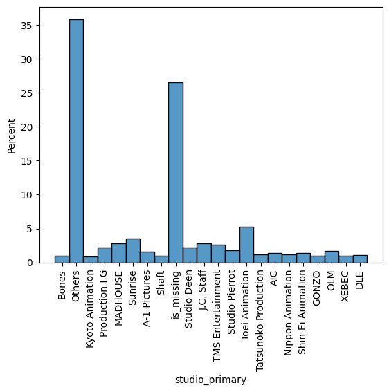

```python
sns.histplot(data=df, x='studio_primary', stat="percent")
plt.xticks(rotation=90);
```

The most frequent categories in this column are Others and is_missing.

### years_running

Number of years the show ran for.

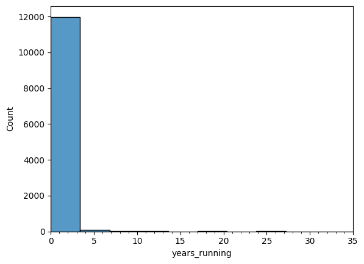

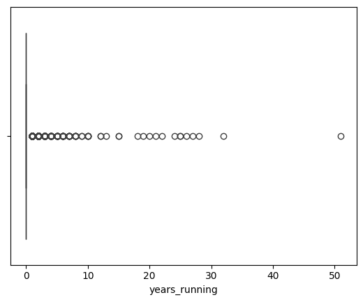

```python
hsplt = sns.histplot(data=df, x='years_running')
plt.xlim(0,35)
hsplt.xaxis.set_minor_locator(ticker.MultipleLocator(1))
plt.show()
sns.boxplot(data=df, x='years_running')
plt.show()
```

A wide majority of the shows in this data set run for less than 5 years.

### watched

Number of users that completed the show.

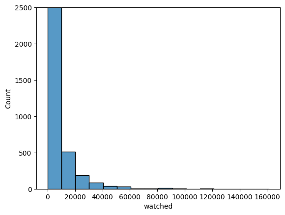

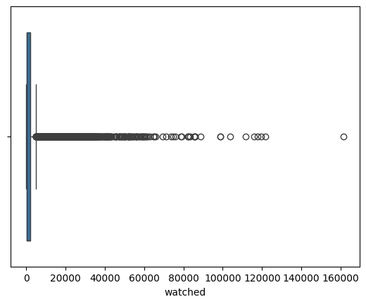

```python
sns.histplot(data=df, x='watched', binwidth=10000)
plt.ylim(0,2500)
plt.show()
sns.boxplot(data=df, x='watched')
plt.show()
```

### watching

Number of users that are watching the anime.

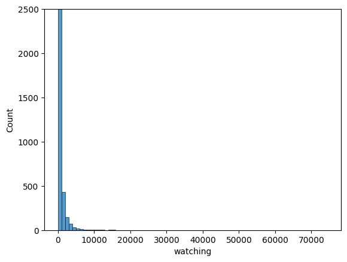

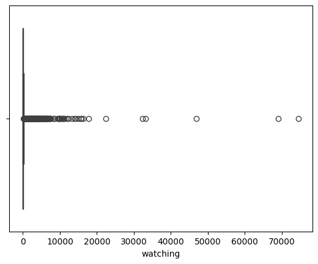

```python
sns.histplot(data=df, x='watching', binwidth=1000)
plt.ylim(0,2500)
plt.show()
sns.boxplot(data=df, x='watching')
plt.show()
```

### wantWatch

Number of users that watn to watch the anime.

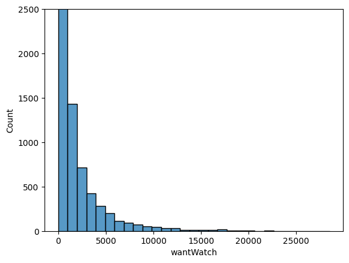

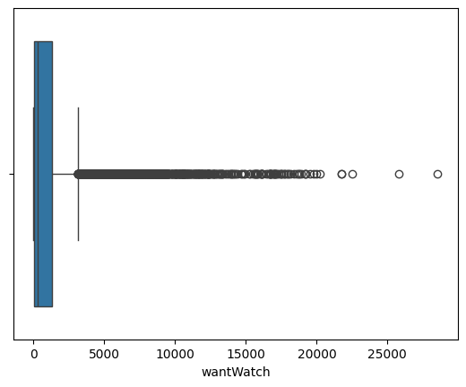

```python
sns.histplot(data=df, x='wantWatch', binwidth=1000)
plt.ylim(0,2500)
plt.show()
sns.boxplot(data=df, x='wantWatch')
plt.show()
```

## Bivariate Analysis

### mediaType and rating

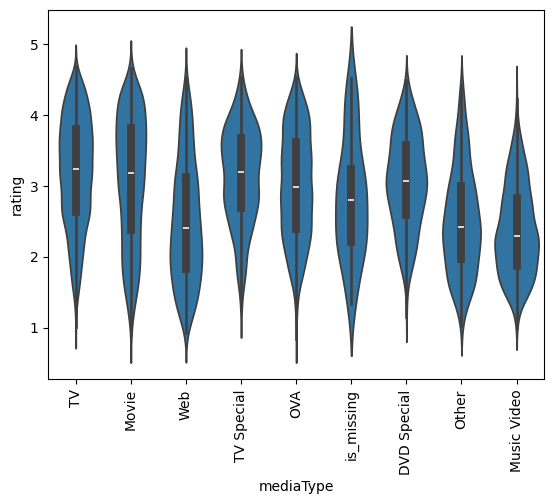

```python
sns.violinplot(data=df, x='mediaType', y='rating')
plt.xticks(rotation=90);
```

```python
rating_by_media = df['rating'].groupby(by=df['mediaType']).median().reset_index(name='median_rating')
print(rating_by_media.sort_values(by='median_rating',ascending=False))
```

```
     mediaType  median_rating
5           TV         3.2460
6   TV Special         3.1925
1        Movie         3.1805
0  DVD Special         3.0740
3          OVA         2.9860
8   is_missing         2.7980
4        Other         2.4245
7          Web         2.4095
2  Music Video         2.2940
```

TV shows and TV Specials have the highest median ratings while web and music video animes have the lowest.

### sznOfRelease and rating

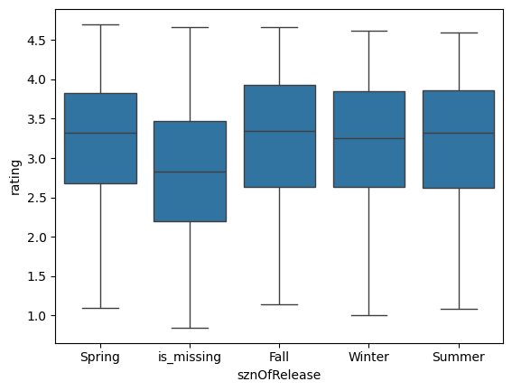

```python
sns.boxplot(data=df, x='sznOfRelease', y='rating')
```

```python
rating_by_season = df['rating'].groupby(by=df['sznOfRelease']).median().reset_index(name='median_rating')
print(rating_by_season.sort_values(by='median_rating',ascending=False))
```

```
  sznOfRelease  median_rating
0         Fall          3.350
2       Summer          3.323
1       Spring          3.322
3       Winter          3.255
4   is_missing          2.829
```

When the data is available, we can see that rating doesn't vary widely based on the season the anime is released.

### studio_primary and rating

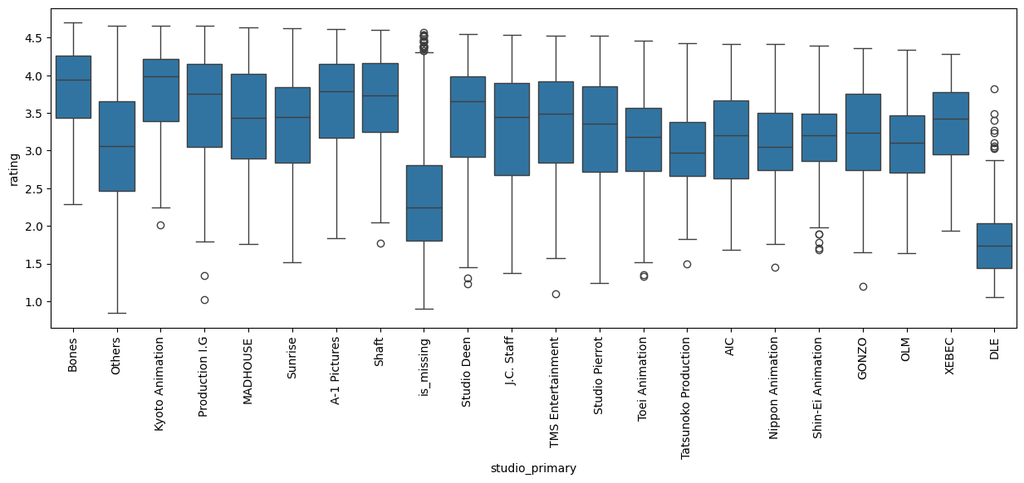

```python
plt.figure(figsize=(15, 5))
sns.boxplot(data=df, x='studio_primary', y='rating')
plt.xticks(rotation=90);
```

```python
primary_studio_rating = df['rating'].groupby(df['studio_primary']).median().reset_index(name='median_rating')
print(primary_studio_rating.sort_values(by='median_rating', ascending=False))
```

```
          studio_primary  median_rating
6        Kyoto Animation         3.9865
2                  Bones         3.9440
0           A-1 Pictures         3.7920
11        Production I.G         3.7560
12                 Shaft         3.7330
14           Studio Deen         3.6565
17     TMS Entertainment         3.4930
5             J.C. Staff         3.4490
16               Sunrise         3.4470
7               MADHOUSE         3.4310
20                 XEBEC         3.4190
15        Studio Pierrot         3.3590
4                  GONZO         3.2395
13     Shin-Ei Animation         3.2050
1                    AIC         3.2050
19        Toei Animation         3.1815
9                    OLM         3.1020
10                Others         3.0640
8       Nippon Animation         3.0490
18  Tatsunoko Production         2.9760
21            is_missing         2.2465
3                    DLE         1.7420
```

### studios_colab and rating

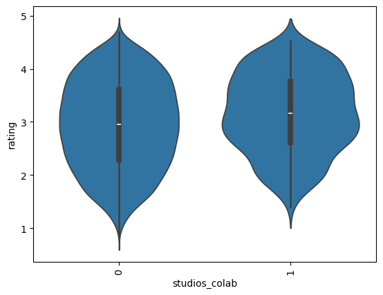

```python
sns.violinplot(data=df, x='studios_colab', y='rating')
plt.xticks(rotation=90);
```

```python
primary_studio_rating = df['rating'].groupby(df['studios_colab']).median().reset_index(name='median_rating')
print(primary_studio_rating.sort_values(by='median_rating', ascending=False))
```

```
   studios_colab  median_rating
1              1         3.1580
0              0         2.9515
```

When studios colab there is a slightly higher median rating then when they don't.

### contentWarn and rating

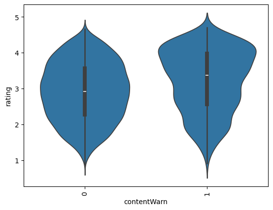

```python
sns.violinplot(data=df, x='contentWarn', y='rating')
plt.xticks(rotation=90);
```

```python
primary_studio_rating = df['rating'].groupby(df['contentWarn']).median().reset_index(name='median_rating')
print(primary_studio_rating.sort_values(by='median_rating', ascending=False))
```

```
   contentWarn  median_rating
1            1         3.3675
0            0         2.9260
```

Anime's that have a content warning have a much higher median rating than those that don't. This is a strong indication that contentWarn will be a strong feature to use when predicting the rating of a show.

### watched and rating

The number of people that watched the anime and the rating.

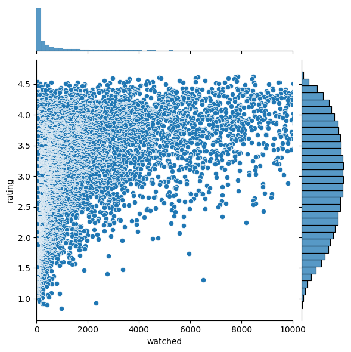

```python
sns.jointplot(data=df, x='watched', y='rating')
plt.xlim(0,10000)
plt.show();
```

### watching and rating

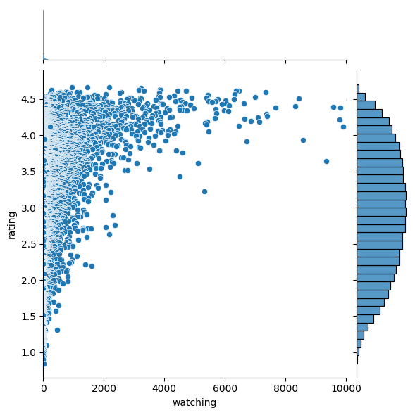

```python
sns.jointplot(data=df, x='watching', y='rating')
plt.xlim(0,10000)
plt.show();
```

RThere appears to be a positive linear relationship between the two features.

### wantWatch and rating

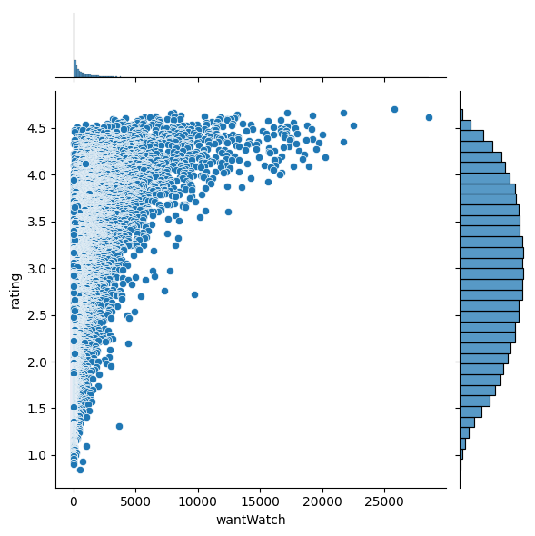

```python
sns.jointplot(data=df, x='wantWatch', y='rating')
#plt.xlim(0,10000)
plt.show();
```

There appears to be a positive linear relationship between the two features.

### dropped and rating

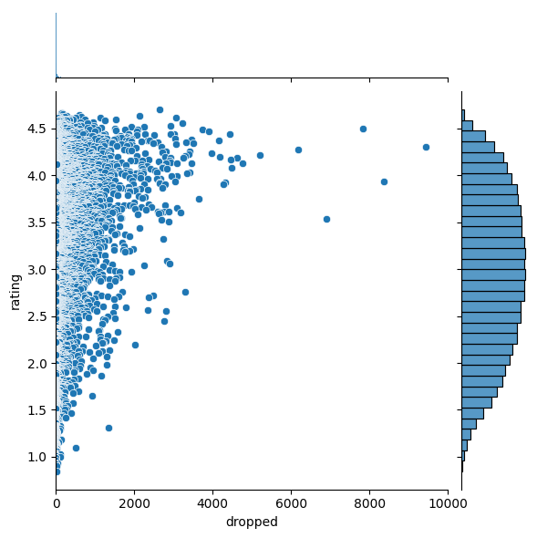

```python
sns.jointplot(data=df, x='dropped', y='rating')
plt.xlim(0,10000)
plt.show();
```

The correlation between these two features appears weak.

### Correlation

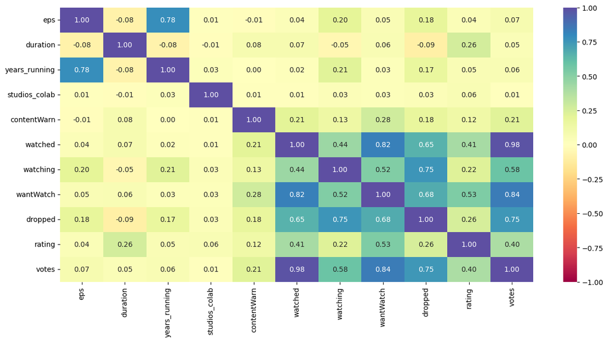

```python
#isolate numerical cols from the df.
num_cols = df.select_dtypes(include="number")
#create a list of columns without tag in them.
no_tags = [item for item in num_cols.columns if "tag" not in item]
plt.figure(figsize=(15, 7))
sns.heatmap(df[no_tags].corr(), annot=True, vmin=-1, vmax=1, fmt=".2f", cmap="Spectral")
```

### Checking the frequency of values in the tags columns.

```python
tag_cols = [item for item in df.columns if "tag" in item]

for col in tag_cols:
  print(df[col].value_counts())
  print("-" * 30)
```

```
tag_Based_on_a_Manga
0    8582
1    3519
Name: count, dtype: int64
------------------------------
tag_Comedy
0    8799
1    3302
Name: count, dtype: int64
------------------------------
tag_Action
0    9303
1    2798
Name: count, dtype: int64
------------------------------
tag_Fantasy
0    9904
1    2197
Name: count, dtype: int64
------------------------------
tag_Sci_Fi
0    10089
1     2012
Name: count, dtype: int64
------------------------------
tag_Shounen
0    10348
1     1753
Name: count, dtype: int64
------------------------------
tag_Original_Work
0    10465
1     1636
Name: count, dtype: int64
------------------------------
tag_Non_Human_Protagonists
0    10740
1     1361
Name: count, dtype: int64
------------------------------
```

[output cut: 80 more lines]

```
tag_Superpowers
0    11561
1      540
Name: count, dtype: int64
------------------------------
tag_Others
0    11004
1     1097
Name: count, dtype: int64
------------------------------
tag_missing
0    11788
1      313
Name: count, dtype: int64
------------------------------
```

## Prediction Model

### Creating dummy variables for the discrete variables

```python
# Drop the title column as it will not be used for prediction and the rating column.
dummies_df = df.drop(['title', 'rating'], axis=1)
#Create the dummy variables for the non-numeric columns.
dummies_df = pd.get_dummies(
    dummies_df,
    columns = dummies_df.select_dtypes(include=['object', 'category']).columns.tolist(),
    drop_first = True,
)
dummies_df.shape
```

```
(12101, 71)
```

### Create X and Y variables

```python
X = dummies_df.values
y = df['rating'].values
```

### Split the data into train and test sets

```python
X_train, X_test, y_train, y_test = train_test_split(X, y, test_size=0.3, random_state=42)
```

```python
print(f"The number of rows in the train data set is {X_train.shape[0]}.")
print(f"The number of rows in the test data set is {X_test.shape[0]}.")
```

```
The number of rows in the train data set is 8470.
The number of rows in the test data set is 3631.
```

```python
scaler = StandardScaler()
#Scale the training data.
X_std_df = scaler.fit_transform(X_train)
```

### Fit the linear model

```python
lin_reg = LinearRegression()
lin_reg.fit(X_std_df, y_train)
```

```
LinearRegression()
```

```python
#Scale the test set.
X_test_std = scaler.transform(X_test)
```

```python
y_pred = lin_reg.predict(X_test_std)
```

### Model Performance Evaluation

```python
#R-squared value
lin_reg.score(X_test_std, y_test)
```

```
0.5266276730401391
```

The initial R2 score is 52%.

```python
rfe = RFE(estimator=LinearRegression(), n_features_to_select=30, verbose=1)
rfe.fit(X_std_df, y_train)
```

[output not shown]

```
RFE(estimator=LinearRegression(), n_features_to_select=30, verbose=1)
```

```python
lin_reg.score(X_test_std, rfe.predict(X_test_std))
```

```
0.9895767030954921
```

```python
print(dummies_df.columns[rfe.support_])
```

```
Index(['duration', 'ongoing', 'years_running', 'contentWarn', 'watched',
       'watching', 'wantWatch', 'dropped', 'votes', 'tag_Based_on_a_Manga',
       'tag_Fantasy', 'tag_Shounen', 'tag_Drama', 'tag_Family_Friendly',
       'tag_Short_Episodes', 'tag_Shorts', 'tag_Slice_of_Life', 'tag_Seinen',
       'tag_Supernatural', 'tag_Animal_Protagonists', 'tag_Ecchi',
       'tag_Based_on_a_Light_Novel', 'mediaType_Music Video', 'mediaType_OVA',
       'studio_primary_DLE', 'studio_primary_Others',
       'studio_primary_Production I.G', 'studio_primary_Sunrise',
       'studio_primary_TMS Entertainment', 'studio_primary_is_missing'],
      dtype='object')
```

Above is a list of the most important features in the dataset. These features are the key in predicited the rating a show will get.

```python
ranking = rfe.ranking_
```

```python
ranked_columns = pd.DataFrame({'Feature': dummies_df.columns, 'Rank': ranking})
```

```python
sorted_ranked_columns = ranked_columns.sort_values(by='Rank')
print(sorted_ranked_columns.head(30))
```

```
                             Feature  Rank
70         studio_primary_is_missing     1
59             studio_primary_Others     1
60     studio_primary_Production I.G     1
40                     mediaType_OVA     1
39             mediaType_Music Video     1
33        tag_Based_on_a_Light_Novel     1
31                         tag_Ecchi     1
30           tag_Animal_Protagonists     1
28                  tag_Supernatural     1
27                        tag_Seinen     1
52                studio_primary_DLE     1
25                        tag_Shorts     1
22                tag_Short_Episodes     1
21               tag_Family_Friendly     1
```

[output cut: 16 more lines]

```python
!jupyter nbconvert --to html /content/AnimeRatingCaseStudy.ipynb
```

```
[NbConvertApp] Converting notebook /content/AnimeRatingCaseStudy.ipynb to html
[NbConvertApp] WARNING | Alternative text is missing on 24 image(s).
[NbConvertApp] Writing 1593675 bytes to /content/AnimeRatingCaseStudy.html
```